# 2a Prova d’Avaluació Contínua (PAC2)

Programari per a l’anàlisi de dades

Robert Buj

22/04/2026

# Secció 1. Fonaments de programació i BBDD (5 punts)

## Exercici 1. Anàlisis de seqüències d’ ADN en una matriu. (1.25 punts)

Una seqüència d’ADN està formada pels caràcters “A”, “C”, “G” i “T”. Suposem que, a més de la transcripció a ARN, volem analitzar diverses seqüències emmagatzemades en forma de matriu. Per a això, es disposa de la següent matriu, on cada fila representa una seqüència d’ADN:

```r
secuencias <- matrix(c(
    "GATTACA",
    "GCGTTA",
    "TTTACG",
    "ACGTACGT"
), ncol = 1)
```

Es demana:

1. (0.25 punts) Recórrer la matriu utilitzant un bucle i mostrar el resultat de cada iteració.

```r
for (i in seq_len(nrow(secuencias))) {
    print(secuencias[i, 1])
}
```

```
## [1] "GATTACA"
## [1] "GCGTTA"
## [1] "TTTACG"
## [1] "ACGTACGT"
```

2. (0.25 punts) A partir de la matriu secuencias definida a l’enunciat, quantes files contenen almenys un nucleòtid “T”?

```r
contador_T <- 0
for (i in seq_len(nrow(secuencias))) {
    if (grepl("T", secuencias[i, 1])) {
        contador_T <- contador_T + 1
    }
}
contador_T
```

```
## [1] 4
```

3. (0.5 punts) Definir una funció anomenada DNA_to_RNA que converteixi una cadena qualsevol d’ADN en ARN substituint totes les “T” per “U” i mostrar el resultat de la funció a partir d’un determinat paràmetre, per exemple, amb el valor “ATTGCTT”. Per assegurar les dades d’entrada, també es demana crear una funció validar_adn que, donada una seqüència, validi que només contingui els caràcters vàlids: “A”, “C”, “G” i “T”. D’aquesta manera, si es detecta algun caràcter diferent, es mostra un missatge d’error i no es processa aquesta seqüència.

```r
validar_adn <- function(seq) {
    if (grepl("^[ACGT]+$", seq)) {
        return(TRUE)
    } else {
        return(FALSE)
    }
}

DNA_to_RNA <- function(dna_seq) {
    if (validar_adn(dna_seq)) {
        rna_seq <- gsub("T", "U", dna_seq)
        return(rna_seq)
    } else {
        stop("Error: La seqüència d'ADN no és vàlida.")
    }
}

# Provar la funció DNA_to_RNA amb una seqüència vàlida
DNA_to_RNA("ATTGCTT")
```

```
## [1] "AUUGCUU"
```

```r
# Provar la funció DNA_to_RNA amb una seqüència no vàlida
tryCatch(
    {
        DNA_to_RNA("ATXGCTT")
    },
    error = function(e) {
        print(e$message)
    }
)
```

```
## [1] "Error: La seqüència d'ADN no és vàlida."
```

4. (0.25 punts) Executar la funció DNA_to_RNA, passant la matriu secuencias com a paràmetre i mostrar el resultat iteració a iteració.

```r
for (i in seq_len(nrow(secuencias))) {
    rna_result <- DNA_to_RNA(secuencias[i, 1])
    print(rna_result)
}
```

```
## [1] "GAUUACA"
## [1] "GCGUUA"
## [1] "UUUACG"
## [1] "ACGUACGU"
```

## Exercici 2. Càlcul de l’índex de normalització d’expressió. (1.25 punts)

Suposem un experiment de RNA-seq, a partir del qual volem normalitzar l’expressió d’un gen respecte al total de lectures de la mostra. Aquest ajust de les dades es realitza per tal que siguin comparables.

Suposem que es defineix l’índex de normalització com:

```
índex = lectures_gen / lectures_totals
```

Cal tenir en compte que aquests valors han de ser positius i numèrics.

Resoleu les següents qüestions:

1. (0.5 punts) Definir una funció en R anomenada `indice_normalizacion` que rebi dos paràmetres:

```
lecturas_gen: nombre de lectures del gen.
lecturas_totales: nombre total de lectures de la mostra.
```

La funció ha de calcular i retornar el valor de l’índex, així com realitzar el control d’errors corresponent.

```r
indice_normalizacion <- function(lecturas_gen, lecturas_totales) {
    if (!is.numeric(lecturas_gen)) {
        stop("Error: El nombre de lectures del gen ha de ser numèric.")
    }
    if (!is.numeric(lecturas_totales)) {
        stop("Error: El nombre total de lectures ha de ser numèric.")
    }
    if (lecturas_gen < 0) {
        stop("Error: El nombre de lectures del gen ha de ser positiu.")
    }
    if (lecturas_totales <= 0) {
        stop("Error: El nombre total de lectures ha de ser major que zero.")
    }
    indice <- lecturas_gen / lecturas_totales
    return(indice)
}
```

2. (0.25 punts) Comprovar el resultat per, per exemple, els següents paràmetres:

```
lecturas_gen = 500
lecturas_totales = 10000
```

Igualment, realitzeu proves amb diferents valors numèrics, no numèrics, etc.

```r
# Prova amb valors vàlids
lecturas_gen <- 500
lecturas_totales <- 10000
indice_result <- indice_normalizacion(lecturas_gen, lecturas_totales)
print(indice_result)
```

```
## [1] 0.05
```

```r
# Prova amb valors no numèrics
tryCatch(
    {
        indice_normalizacion("zero", 10000)
    },
    error = function(e) {
        print(e$message)
    }
)
```

```
## [1] "Error: El nombre de lectures del gen ha de ser numèric."
```

```r
# Prova amb valors negatius
tryCatch(
    {
        indice_normalizacion(-100, 10000)
    },
    error = function(e) {
        print(e$message)
    }
)
```

```
## [1] "Error: El nombre de lectures del gen ha de ser positiu."
```

```r
# Prova amb total de lectures zero
tryCatch(
    {
        indice_normalizacion(500, 0)
    },
    error = function(e) {
        print(e$message)
    }
)
```

```
## [1] "Error: El nombre total de lectures ha de ser major que zero."
```

3. (0.5 punts) Com modificaríeu el codi per permetre a l’usuari introduir valors?

```r
lecturas_gen <- as.numeric(readline(
    prompt = "Introdueix el nombre de lectures del gen: "
))
```

```
## Introdueix el nombre de lectures del gen:
```

```r
lecturas_totales <- as.numeric(readline(
    prompt = "Introdueix el nombre total de lectures de la mostra: "
))
```

```
## Introdueix el nombre total de lectures de la mostra:
```

```r
tryCatch(
    {
        indice_result <- indice_normalizacion(lecturas_gen, lecturas_totales)
        print(paste("L'índex de normalització és:", indice_result))
    },
    error = function(e) {
        print(e$message)
    }
)
```

```
## [1] "valor ausente donde TRUE/FALSE es necesario"
```

## Exercici 3. Anàlisi farmacocinètica amb SQL en R (2.5 punts)

Disposem del conjunt de dades Theoph del paquet datasets, que conté dades d’un experiment de farmacocinètica de la teofilina en diversos pacients. La teofilina s’utilitza per prevenir i tractar les sibilàncies, la manca d’alè i l’opressió al pit causada per l’asma, la bronquitis crònica, l’emfisema i altres malalties pulmonars.

En el conjunt de dades a treballar, cada fila representa una mesura de concentració (conc) en un temps (time) per a un determinat subjecte (subject).

Es demana:

1. (0.25 punts) Carregar el paquet datasets de RStudio i el conjunt de dades Theoph, així com les llibreries necessàries, DBI i RSQLite, per executar consultes SQL en R. Mostreu el conjunt de dades Theoph.

```r
data("Theoph")
print(Theoph)
```

```
##     Subject   Wt Dose  Time  conc
## 1         1 79.6 4.02  0.00  0.74
## 2         1 79.6 4.02  0.25  2.84
## 3         1 79.6 4.02  0.57  6.57
## 4         1 79.6 4.02  1.12 10.50
## 5         1 79.6 4.02  2.02  9.66
## 6         1 79.6 4.02  3.82  8.58
## 7         1 79.6 4.02  5.10  8.36
## 8         1 79.6 4.02  7.03  7.47
## 9         1 79.6 4.02  9.05  6.89
## 10        1 79.6 4.02 12.12  5.94
## 11        1 79.6 4.02 24.37  3.28
## 12        2 72.4 4.40  0.00  0.00
## 13        2 72.4 4.40  0.27  1.72
## 14        2 72.4 4.40  0.52  7.91
```

[output cut: 118 more lines]

2. (0.25 punts) Establir una connexió a una base de dades SQLite en memòria, carregar el conjunt de dades Theoph i escriure’l com una taula anomenada ‘Theoph’ a la base de dades.

```r
con <- dbConnect(RSQLite::SQLite(), ":memory:")
dbWriteTable(con, "Theoph", as.data.frame(Theoph), row.names = FALSE)
```

3. (0.5 punts) Realitzar una consulta SQL que calculi la concentració mitjana (conc) per a cada subjecte. El resultat ha de mostrar: Subject, conc_media.

```r
query <- "
    SELECT subject, AVG(conc) AS conc_media
    FROM Theoph
    GROUP BY subject
"
result <- dbGetQuery(con, query)
print(result)
```

```
##    Subject conc_media
## 1        1   6.439091
## 2       10   5.930909
## 3       11   4.510909
## 4       12   5.410000
## 5        2   4.823636
## 6        3   5.086364
## 7        4   4.940000
## 8        5   5.782727
## 9        6   3.525455
## 10       7   3.910909
## 11       8   4.271818
## 12       9   4.893636
```

4. (0.5 punts) Realitzar una consulta en SQL per obtenir el temps en què ocorre la concentració màxima per pacient, és a dir, per a cada subjecte, obtenir el temps associat a la seva concentració màxima.

```r
query_max_conc <- "
    SELECT subject, time
    FROM Theoph
    WHERE (subject, conc) IN (
        SELECT subject, MAX(conc)
        FROM Theoph
        GROUP BY subject
    )
"
result_max_conc <- dbGetQuery(con, query_max_conc)
print(result_max_conc)
```

```
##    Subject Time
## 1        1 1.12
## 2        2 1.92
## 3        3 1.02
## 4        4 1.07
## 5        5 1.00
## 6        6 1.15
## 7        7 3.48
## 8        8 2.02
## 9        9 0.63
## 10      10 3.55
## 11      11 0.98
## 12      12 3.52
```

5. (0.5 punts) Realitzar una consulta en SQL que filtri les observacions en un interval de temps; per exemple, es demana obtenir concentracions entre 2 i 6 hores.

```r
query_time_interval <- "
    SELECT *
    FROM Theoph
    WHERE time BETWEEN 2 AND 6
"
result_time_interval <- dbGetQuery(con, query_time_interval)
print(result_time_interval)
```

```
##    Subject   Wt Dose Time  conc
## 1        1 79.6 4.02 2.02  9.66
## 2        1 79.6 4.02 3.82  8.58
## 3        1 79.6 4.02 5.10  8.36
## 4        2 72.4 4.40 3.50  6.85
## 5        2 72.4 4.40 5.02  6.08
## 6        3 70.5 4.53 2.02  7.80
## 7        3 70.5 4.53 3.62  7.50
## 8        3 70.5 4.53 5.08  6.20
## 9        4 72.7 4.40 2.13  8.38
## 10       4 72.7 4.40 3.50  7.54
## 11       4 72.7 4.40 5.02  6.88
## 12       5 54.6 5.86 2.02  9.33
## 13       5 54.6 5.86 3.50  8.74
## 14       5 54.6 5.86 5.02  7.56
```

[output cut: 20 more lines]

6. (0.5 punts) Realitzar una consulta en SQL per mostrar el nombre d’observacions per pacient.

```r
query_count_observations <- "
    SELECT subject, COUNT(*) AS num_observations
    FROM Theoph
    GROUP BY subject
"
result_count_observations <- dbGetQuery(con, query_count_observations)
print(result_count_observations)
```

```
##    Subject num_observations
## 1        1               11
## 2       10               11
## 3       11               11
## 4       12               11
## 5        2               11
## 6        3               11
## 7        4               11
## 8        5               11
## 9        6               11
## 10       7               11
## 11       8               11
## 12       9               11
```

Un cop finalitzat el llistat de consultes, recordeu tancar la connexió.

```r
dbDisconnect(con)
```

# Secció 2: Probabilitat i simulacions (5 punts)

## Exercici 4. Temps d’eliminació d’un fàrmac en sang (2.5 punts)

L’objectiu d’aquest exercici és estudiar el temps que tarda un fàrmac a reduir la seva concentració en sang després de la seva administració.

Suposem que el temps, en hores, segueix una distribució log-normal i, en condicions normals, la mitjana meanlog és de 1.0 i la desviació típica sdlog de 0.25.

S’ha detectat que els valors d’aquests paràmetres en pacients amb insuficiència renal serien:

```
meanlog = 1.4
sdlog = 0.35
```

Nota.- La distribució log-normal és més adequada per tractar temps biològics, creixement bacterià, etc.

Es demana:

1. (0.5 punts) Representar gràficament les densitats de les dues distribucions. Comentar les diferències observades.

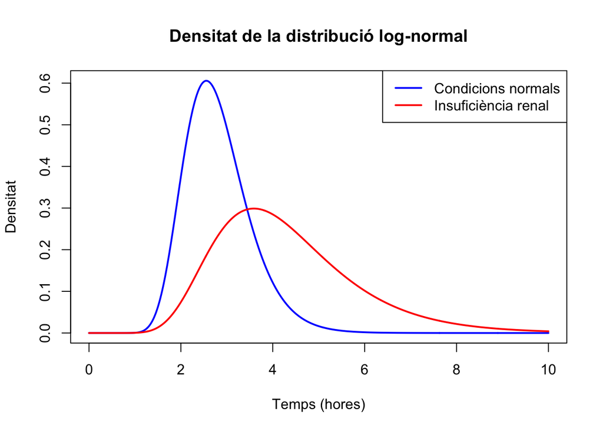

```r
x <- seq(0, 10, length.out = 1000)
dens_normal <- dlnorm(x, meanlog = 1.0, sdlog = 0.25)
dens_insuf_renal <- dlnorm(x, meanlog = 1.4, sdlog = 0.35)
plot(
    x,
    dens_normal,
    type = "l",
    col = "blue",
    lwd = 2,
    xlab = "Temps (hores)",
    ylab = "Densitat",
    main = "Densitat de la distribució log-normal"
)
lines(x, dens_insuf_renal, col = "red", lwd = 2)
legend(
    "topright",
    legend = c("Condicions normals", "Insuficiència renal"),
    col = c("blue", "red"),
    lwd = 2
)
```

2. (0.5 punts) Calcular la probabilitat que el fàrmac s’elimini en menys de 2 hores i en més de 6 hores, en ambdós casos. Interpretar els resultats.

```r
# Probabilitat d'eliminació en menys de 2 hores
prob_menys_2_normal <- plnorm(2, meanlog = 1.0, sdlog = 0.25)
prob_menys_2_insuf_renal <- plnorm(2, meanlog = 1.4, sdlog = 0.35)
# Probabilitat d'eliminació en més de 6 hores
prob_mes_6_normal <- 1 - plnorm(6, meanlog = 1.0, sdlog = 0.25)
prob_mes_6_insuf_renal <- 1 - plnorm(6, meanlog = 1.4, sdlog = 0.35)
print(paste(
    "Probabilitat d'eliminació en menys de 2 hores (condicions normals):",
    prob_menys_2_normal
))
```

```
## [1] "Probabilitat d'eliminació en menys de 2 hores (condicions normals): 0.1098340248681"
```

```r
print(paste(
    "Probabilitat d'eliminació en menys de 2 hores (insuficiència renal):",
    prob_menys_2_insuf_renal
))
```

```
## [1] "Probabilitat d'eliminació en menys de 2 hores (insuficiència renal): 0.0217135124904396"
```

```r
print(paste(
    "Probabilitat d'eliminació en més de 6 hores (condicions normals):",
    prob_mes_6_normal
))
```

```
## [1] "Probabilitat d'eliminació en més de 6 hores (condicions normals): 0.00077000129321736"
```

```r
print(paste(
    "Probabilitat d'eliminació en més de 6 hores (insuficiència renal):",
    prob_mes_6_insuf_renal
))
```

```
## [1] "Probabilitat d'eliminació en més de 6 hores (insuficiència renal): 0.131503365073528"
```

3. (1 punt) Realitzar 10.000 simulacions en cada escenari i estimar la mitjana, la variància i els percentils 25%, 50% i 75%. Comparar amb els valors teòrics de la mitjana i la variància de la distribució log-normal.

```r
set.seed(123) # Per reproducibilitat
sim_normal <- rlnorm(10000, meanlog = 1.0, sdlog = 0.25)
sim_insuf_renal <- rlnorm(10000, meanlog = 1.4, sdlog = 0.35)

# Estimació de la mitjana, variància i percentils
estim_normal <- c(
    mean = mean(sim_normal),
    var = var(sim_normal),
    p25 = quantile(sim_normal, 0.25),
    p50 = quantile(sim_normal, 0.5),
    p75 = quantile(sim_normal, 0.75)
)
estim_insuf_renal <- c(
    mean = mean(sim_insuf_renal),
    var = var(sim_insuf_renal),
    p25 = quantile(sim_insuf_renal, 0.25),
    p50 = quantile(sim_insuf_renal, 0.5),
    p75 = quantile(sim_insuf_renal, 0.75)
)
print("Estimacions per condicions normals:")
```

```
## [1] "Estimacions per condicions normals:"
```

```r
print(estim_normal)
```

```
##      mean       var   p25.25%   p50.50%   p75.75%
## 2.8027262 0.5066408 2.3002268 2.7107564 3.2166384
```

```r
print("Estimacions per insuficiència renal:")
```

```
## [1] "Estimacions per insuficiència renal:"
```

```r
print(estim_insuf_renal)
```

```
##     mean      var  p25.25%  p50.50%  p75.75%
## 4.299069 2.431542 3.197576 4.029900 5.129555
```

```r
# Càlcul de la mitjana i variància teòrica de la distribució log-normal
teo_mean_normal <- exp(1.0 + (0.25^2) / 2)
teo_var_normal <- (exp(0.25^2) - 1) * exp(2 * 1.0 + 0.25^2)
teo_mean_insuf_renal <- exp(1.4 + (0.35^2) / 2)
teo_var_insuf_renal <- (exp(0.35^2) - 1) * exp(2 * 1.4 + 0.35^2)
print(paste("Mitjana teòrica (condicions normals):", teo_mean_normal))
```

```
## [1] "Mitjana teòrica (condicions normals): 2.80456935623723"
```

```r
print(paste("Variància teòrica (condicions normals):", teo_var_normal))
```

```
## [1] "Variància teòrica (condicions normals): 0.507288214182372"
```

```r
print(paste("Mitjana teòrica (insuficiència renal):", teo_mean_insuf_renal))
```

```
## [1] "Mitjana teòrica (insuficiència renal): 4.31134534318864"
```

```r
print(paste("Variància teòrica (insuficiència renal):", teo_var_insuf_renal))
```

```
## [1] "Variància teòrica (insuficiència renal): 2.42233253464517"
```

```r
# Comparació dels resultats en una taula amb kable
comparacio <- data.frame(
    Escenari = c("Condicions normals", "Insuficiència renal"),
    Mitjana_Estimada = c(estim_normal["mean"], estim_insuf_renal["mean"]),
    Variancia_Estimada = c(estim_normal["var"], estim_insuf_renal["var"]),
    Mitjana_Teorica = c(teo_mean_normal, teo_mean_insuf_renal),
    Variancia_Teorica = c(teo_var_normal, teo_var_insuf_renal)
)
comparacio |>
    kable(
        caption = "Comparació de les estimacions amb els valors teòrics",
        col.names = c(
            "Escenari", "Mitjana Estimada", "Variància Estimada",
            "Mitjana Teòrica", "Variància Teòrica"
        )
    ) |>
    kable_styling(full_width = FALSE, position = "center")
```

Comparació de les estimacions amb els valors teòrics

| Escenari | Mitjana Estimada | Variància Estimada | Mitjana Teòrica | Variància Teòrica |
| --- | --- | --- | --- | --- |
| Condicions normals | 2.802726 | 0.5066408 | 2.804569 | 0.5072882 |
| Insuficiència renal | 4.299069 | 2.4315417 | 4.311345 | 2.4223325 |

4. (0.5 punts) Fer una breu reflexió de l’estudi realitzat a partir dels resultats anteriors.

Els resultats mostren que l’escenari d’insuficiència renal desplaça la distribució cap a la dreta i incrementa la dispersió, de manera que el temps d’eliminació tendeix a ser més llarg i més variable. Això es reflecteix en una probabilitat menor que el fàrmac s’elimini ràpidament i una probabilitat més gran de persistir més enllà de 6 hores. Les simulacions són coherents amb els valors teòrics, de manera que confirmen el comportament esperat de la distribució log-normal en ambdós escenaris.

## Exercici 5. Resposta a un tractament analgèsic en dolor crònic (2.5 punts)

Cal avaluar l’eficàcia d’un nou tractament analgèsic en pacients amb dolor crònic, del qual sabem que no tots els pacients responen igual.

A partir d’estudis previs, el 25% dels pacients “responen al tractament”, és a dir, experimenten una reducció significativa del dolor. En canvi, el 75% restant “no responen al tractament”.

En pacients que responen al tractament, la probabilitat de presentar millora clínica després d’una setmana és del 80%. En la resta de pacients, la probabilitat de presentar millora (efecte placebo o variabilitat) és del 20%.

```r
set.seed(123) # Per reproducibilitat
# Paràmetres
n_pacients <- 120
prob_resposta <- 0.25
prob_millora_resposta <- 0.80
prob_millora_no_resposta <- 0.20
# Simulació
simulacions <- 10000
resultats <- replicate(simulacions, {
    pacients <- rbinom(n_pacients, 1, prob_resposta)
    millora <- ifelse(
        pacients == 1,
        rbinom(n_pacients, 1, prob_millora_resposta),
        rbinom(n_pacients, 1, prob_millora_no_resposta)
    )
    sum(millora)
})
# Probabilitat que almenys 50 reportin millora
prob_almenys_50 <- mean(resultats >= 50)
print(paste("Probabilitat que almenys 50 reportin millora (simulació):", prob_almenys_50))
```

```
## [1] "Probabilitat que almenys 50 reportin millora (simulació): 0.0769"
```

2. (0.5 punts) Si seleccionem 30 pacients amb resposta al tractament, quina és la probabilitat que almenys 25 millorin? I si seleccionem 80 pacients que no responen al tractament, quina és la probabilitat que com a màxim 25 millorin?

```r
set.seed(123) # Per reproducibilitat
# Paràmetres
n_resposta <- 30
n_no_resposta <- 80
# Simulació per pacients que responen al tractament
simulacions_resposta <- replicate(simulacions, {
    millora_resposta <- rbinom(n_resposta, 1, prob_millora_resposta)
    sum(millora_resposta)
})
prob_almenys_25_resposta <- mean(simulacions_resposta >= 25)
print(paste(
    "Probabilitat que almenys 25 millorin entre els que responen al tractament:",
    prob_almenys_25_resposta
))
```

```
## [1] "Probabilitat que almenys 25 millorin entre els que responen al tractament: 0.4275"
```

```r
# Simulació per pacients que no responen al tractament
simulacions_no_resposta <- replicate(simulacions, {
    millora_no_resposta <- rbinom(n_no_resposta, 1, prob_millora_no_resposta)
    sum(millora_no_resposta)
})
prob_maxim_25_no_resposta <- mean(simulacions_no_resposta <= 25)
print(paste(
    "Probabilitat que com a màxim 25 millorin entre els que no responen al tractament:",
    prob_maxim_25_no_resposta
))
```

```
## [1] "Probabilitat que com a màxim 25 millorin entre els que no responen al tractament: 0.9951"
```

3. (1 punt) Representar la distribució del nombre de pacients que milloren en ambdós grups i comentar els resultats.

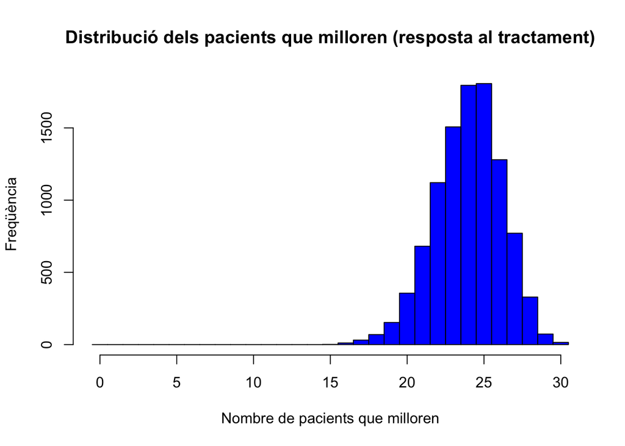

```r
hist(
    simulacions_resposta,
    breaks = seq(-0.5, n_resposta + 0.5, by = 1),
    col = "blue",
    main = "Distribució dels pacients que milloren (resposta al tractament)",
    xlab = "Nombre de pacients que milloren",
    ylab = "Freqüència"
)
```

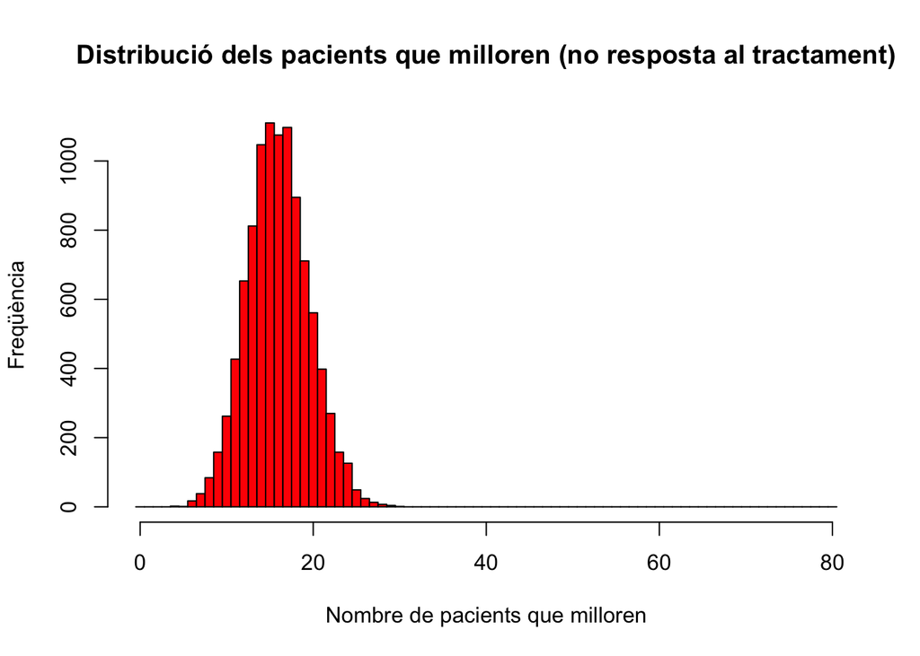

```r
hist(
    simulacions_no_resposta,
    breaks = seq(-0.5, n_no_resposta + 0.5, by = 1),
    col = "red",
    main = "Distribució dels pacients que milloren (no resposta al tractament)",
    xlab = "Nombre de pacients que milloren",
    ylab = "Freqüència"
)
```

4. (0.5 punts) Fer una breu reflexió de l’estudi realitzat a partir dels resultats anteriors.

L’estudi indica que la resposta al tractament té un efecte clar sobre la probabilitat de millora: els pacients que responen al tractament presenten una proporció de millora molt superior als que no responen. Per això, la distribució del nombre de pacients que milloren queda més desplaçada cap a valors alts en el grup de resposta. En canvi, en el grup de no resposta la millora continua existint, però amb una probabilitat molt més baixa i més compatible amb variabilitat o efecte placebo.